# Исследование объявлений о продаже квартир

#### Устранение анамальных значений в столбце living_area

```python
data['living_area'].describe()
```

```
count    23235.000000
mean        33.222347
std         17.109813
min          2.000000
25%         19.000000
50%         30.000000
75%         42.000000
max        164.700000
Name: living_area, dtype: float64
```

```python
drop_living_area = data.query('living_area < 10').index
```

```python
data.drop(drop_living_area, inplace=True, axis=0)
```

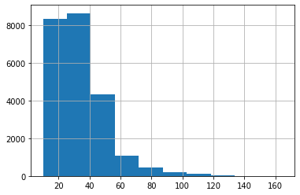

```python
data['living_area'].hist()
```

**Удалены значения как аномальные, где жилая площадь мень 10 кв.м**

#### Устранение анамальных значений в столбце kitchen_area

```python
data['kitchen_area'].describe()
```

```
count    23212.000000
mean        10.240313
std          5.155686
min          1.300000
25%          7.000000
50%          9.000000
75%         11.782521
max         75.000000
Name: kitchen_area, dtype: float64
```

```python
data.query('kitchen_area < 3 or kitchen_area >60')
```

|  | total_images | last_price | total_area | first_day_exposition | rooms | ceiling_height | floors_total | living_area | floor | is_apartment | ... | balcony | locality_name | airports_nearest | city_centers_nearest | parks_around_3000 | parks_nearest | ponds_around_3000 | ponds_nearest | days_exposition | ceiling_height2 |
| --- | --- | --- | --- | --- | --- | --- | --- | --- | --- | --- | --- | --- | --- | --- | --- | --- | --- | --- | --- | --- | --- |
| 906 | 15 | 2600000 | 27.00 | 2017-07-10 | 1 | 2.75 | 23 | 18.0 | 18 | False | ... | 0 | Санкт-Петербург | 22131.0 | 17459.0 | 0.0 | NaN | 1.0 | 411.0 | 10.0 | (2, 5] |
| 6262 | 9 | 3100000 | 24.00 | 2018-06-25 | 2 | 3.00 | 5 | 16.0 | 5 | False | ... | 0 | Санкт-Петербург | 31960.0 | 4914.0 | 2.0 | 426.0 | 1.0 | 936.0 | 54.0 | (2, 5] |
| 7950 | 3 | 5967734 | 66.40 | 2017-02-07 | 2 | 2.70 | 4 | 44.4 | 2 | False | ... | 0 | Санкт-Петербург | 44870.0 | 20802.0 | 0.0 | NaN | 0.0 | NaN | 335.0 | (2, 5] |
| 9138 | 17 | 2920000 | 23.29 | 2018-12-12 | 1 | 2.70 | 3 | 21.0 | 1 | False | ... | 0 | Санкт-Петербург | 19506.0 | 4008.0 | 0.0 | NaN | 2.0 | 45.0 | 107.0 | (2, 5] |
| 11033 | 6 | 5350000 | 32.00 | 2016-04-20 | 1 | 2.70 | 14 | 16.0 | 10 | False | ... | 0 | Санкт-Петербург | 19008.0 | 3953.0 | 0.0 | NaN | 1.0 | 69.0 | 210.0 | (2, 5] |
| 14644 | 17 | 47000000 | 150.00 | 2017-02-28 | 4 | 3.70 | 6 | 58.0 | 5 | False | ... | 1 | Санкт-Петербург | 16085.0 | 7616.0 | 0.0 | NaN | 0.0 | NaN | 507.0 | (2, 5] |
| 14900 | 20 | 25900000 | 125.60 | 2018-08-14 | 2 | 4.00 | 4 | 42.7 | 4 | False | ... | 2 | Пушкин | 13426.0 | 25580.0 | 0.0 | NaN | 0.0 | NaN | 194.0 | (2, 5] |
| 15780 | 9 | 12990000 | 119.60 | 2017-03-13 | 3 | 3.00 | 5 | 36.4 | 4 | False | ... | 4 | Пушкин | 18616.0 | 30770.0 | 1.0 | 569.0 | 0.0 | NaN | NaN | (2, 5] |
| 16367 | 2 | 2720000 | 25.70 | 2017-10-30 | 1 | 2.70 | 19 | 22.6 | 11 | False | ... | 0 | Санкт-Петербург | 14472.0 | 13268.0 | 0.0 | NaN | 0.0 | NaN | 109.0 | (2, 5] |
| 17834 | 5 | 2940000 | 34.70 | 2017-10-09 | 1 | 2.70 | 26 | 15.5 | 14 | False | ... | 1 | посёлок Мурино | NaN | NaN | NaN | NaN | NaN | NaN | 318.0 | (2, 5] |
| 18447 | 17 | 21800000 | 187.00 | 2018-01-14 | 5 | 2.70 | 4 | 120.0 | 4 | False | ... | 0 | Санкт-Петербург | 43758.0 | 15461.0 | 1.0 | 756.0 | 2.0 | 278.0 | NaN | (2, 5] |
| 19130 | 11 | 40000000 | 153.00 | 2017-09-02 | 3 | 3.30 | 10 | 45.2 | 7 | False | ... | 2 | Санкт-Петербург | NaN | NaN | NaN | NaN | NaN | NaN | 455.0 | (2, 5] |
| 19499 | 10 | 8000000 | 118.00 | 2017-08-31 | 3 | 3.00 | 5 | 36.0 | 4 | False | ... | 4 | Пушкин | 18616.0 | 30770.0 | 1.0 | 569.0 | 0.0 | NaN | 7.0 | (2, 5] |
| 20217 | 7 | 4250000 | 28.50 | 2019-05-01 | 1 | 2.80 | 14 | 19.5 | 10 | False | ... | 0 | Санкт-Петербург | 37199.0 | 12721.0 | 0.0 | NaN | 0.0 | NaN | NaN | (2, 5] |
| 21419 | 4 | 1870000 | 20.00 | 2018-03-06 | 1 | 2.50 | 5 | 14.0 | 1 | False | ... | 0 | Санкт-Петербург | 16652.0 | 15654.0 | 1.0 | 619.0 | 1.0 | 937.0 | 45.0 | (2, 5] |
| 22980 | 19 | 24500000 | 155.40 | 2017-10-10 | 3 | 3.00 | 4 | 72.0 | 2 | False | ... | 0 | Санкт-Петербург | 43758.0 | 15461.0 | 1.0 | 756.0 | 2.0 | 278.0 | 325.0 | (2, 5] |

16 rows × 23 columns

```python
drop_kitche_area=data.query('kitchen_area < 3 or kitchen_area >60').index
```

```python
data.drop(drop_kitche_area, inplace=True, axis=0)
```

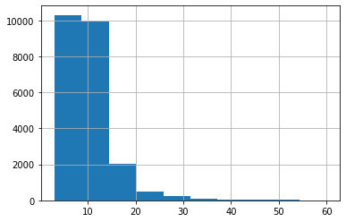

```python
data['kitchen_area'].hist()
```

### Посчитайте и добавьте в таблицу новые столбцы

- **price_one_square_meter:** цена одного квадратного метра;
- **exposition_weekday:** день недели публикации объявления (0 — понедельник, 1 — вторник и так далее);
- **exposition_month:** месяц публикации объявления;
- **exposition_year:** год публикации объявления;
- **floor_category:** тип этажа квартиры (значения — «первый», «последний», «другой»);
- **city_centers_nearest_km:** расстояние до центра города в километрах (переведите из м в км и округлите до целых значений).

#### Добавим столбец - price_one_square_meter

```python
data['price_one_square_meter'] = data['last_price'] / data['total_area']
# округлим значение до 2 знаков после запятой
data['price_one_square_meter'] = data['price_one_square_meter'].round(2)
data['price_one_square_meter'].head(10)
```

```
0     120370.37
1      82920.79
2      92785.71
4     100000.00
5      95065.79
6      99195.71
7     110544.69
8      87454.76
9      88524.59
10    127525.25
Name: price_one_square_meter, dtype: float64
```

#### Добавим столбец - exposition_weekday

```python
# Добавим столбец с днем недели публикации объявления
data['exposition_weekday'] = data['first_day_exposition'].dt.weekday
```

#### Добавим столбец - exposition_month

```python
# Добавим столбец с месяцем публикации объявления
data['exposition_month'] = data['first_day_exposition'].dt.month
```

#### Добавим столбец - exposition_year

```python
# Добавим столбец с годом публикации объявления
data['exposition_year'] = data['first_day_exposition'].dt.year
```

```python
data.head(10)
```

|  | total_images | last_price | total_area | first_day_exposition | rooms | ceiling_height | floors_total | living_area | floor | is_apartment | ... | parks_around_3000 | parks_nearest | ponds_around_3000 | ponds_nearest | days_exposition | ceiling_height2 | price_one_square_meter | exposition_weekday | exposition_month | exposition_year |
| --- | --- | --- | --- | --- | --- | --- | --- | --- | --- | --- | --- | --- | --- | --- | --- | --- | --- | --- | --- | --- | --- |
| 0 | 20 | 13000000 | 108.00 | 2019-03-07 | 3 | 2.700 | 16 | 51.00000 | 8 | False | ... | 1.0 | 482.0 | 2.0 | 755.0 | NaN | (2, 5] | 120370.37 | 3 | 3 | 2019 |
| 1 | 7 | 3350000 | 40.40 | 2018-12-04 | 1 | 2.615 | 11 | 18.60000 | 1 | False | ... | 0.0 | NaN | 0.0 | NaN | 81.0 | (2, 5] | 82920.79 | 1 | 12 | 2018 |
| 2 | 10 | 5196000 | 56.00 | 2015-08-20 | 2 | 2.700 | 5 | 34.30000 | 4 | False | ... | 1.0 | 90.0 | 2.0 | 574.0 | 558.0 | (2, 5] | 92785.71 | 3 | 8 | 2015 |
| 4 | 2 | 10000000 | 100.00 | 2018-06-19 | 2 | 3.030 | 14 | 32.00000 | 13 | False | ... | 2.0 | 112.0 | 1.0 | 48.0 | 121.0 | (2, 5] | 100000.00 | 1 | 6 | 2018 |
| 5 | 10 | 2890000 | 30.40 | 2018-09-10 | 1 | 2.600 | 12 | 14.40000 | 5 | False | ... | NaN | NaN | NaN | NaN | 55.0 | (2, 5] | 95065.79 | 0 | 9 | 2018 |
| 6 | 6 | 3700000 | 37.30 | 2017-11-02 | 1 | 2.640 | 26 | 10.60000 | 6 | False | ... | 0.0 | NaN | 0.0 | NaN | 155.0 | (2, 5] | 99195.71 | 3 | 11 | 2017 |
| 7 | 5 | 7915000 | 71.60 | 2019-04-18 | 2 | 2.700 | 24 | 40.89605 | 22 | False | ... | 0.0 | NaN | 0.0 | NaN | NaN | (2, 5] | 110544.69 | 3 | 4 | 2019 |
| 8 | 20 | 2900000 | 33.16 | 2018-05-23 | 1 | 2.700 | 27 | 15.43000 | 26 | False | ... | NaN | NaN | NaN | NaN | 189.0 | (2, 5] | 87454.76 | 2 | 5 | 2018 |
| 9 | 18 | 5400000 | 61.00 | 2017-02-26 | 3 | 2.500 | 9 | 43.60000 | 7 | False | ... | 0.0 | NaN | 0.0 | NaN | 289.0 | (2, 5] | 88524.59 | 6 | 2 | 2017 |
| 10 | 5 | 5050000 | 39.60 | 2017-11-16 | 1 | 2.670 | 12 | 20.30000 | 3 | False | ... | 1.0 | 310.0 | 2.0 | 553.0 | 137.0 | (2, 5] | 127525.25 | 3 | 11 | 2017 |

10 rows × 27 columns

#### Добавим столбец - floor_category

```python
# Функция для категоризации этажности в доме
def get_floor_category(row):
    floor = row['floor']
    floors_total = row['floors_total']
    if floor == 1:
        return 'первый'
    elif floor == floors_total:
        return 'последний'
    else:
        return 'другой'
```

```python
# Добавляем столбец с категорией этажа квартиры
data['floor_category'] = data.apply(get_floor_category, axis=1)
```

#### Добавим столбец - city_centers_nearest_km

```python
data['city_centers_nearest_km'] = round(data['city_centers_nearest'] / 1000)
```

```python
data.head(10)
```

|  | total_images | last_price | total_area | first_day_exposition | rooms | ceiling_height | floors_total | living_area | floor | is_apartment | ... | ponds_around_3000 | ponds_nearest | days_exposition | ceiling_height2 | price_one_square_meter | exposition_weekday | exposition_month | exposition_year | floor_category | city_centers_nearest_km |
| --- | --- | --- | --- | --- | --- | --- | --- | --- | --- | --- | --- | --- | --- | --- | --- | --- | --- | --- | --- | --- | --- |
| 0 | 20 | 13000000 | 108.00 | 2019-03-07 | 3 | 2.700 | 16 | 51.00000 | 8 | False | ... | 2.0 | 755.0 | NaN | (2, 5] | 120370.37 | 3 | 3 | 2019 | другой | 16.0 |
| 1 | 7 | 3350000 | 40.40 | 2018-12-04 | 1 | 2.615 | 11 | 18.60000 | 1 | False | ... | 0.0 | NaN | 81.0 | (2, 5] | 82920.79 | 1 | 12 | 2018 | первый | 19.0 |
| 2 | 10 | 5196000 | 56.00 | 2015-08-20 | 2 | 2.700 | 5 | 34.30000 | 4 | False | ... | 2.0 | 574.0 | 558.0 | (2, 5] | 92785.71 | 3 | 8 | 2015 | другой | 14.0 |
| 4 | 2 | 10000000 | 100.00 | 2018-06-19 | 2 | 3.030 | 14 | 32.00000 | 13 | False | ... | 1.0 | 48.0 | 121.0 | (2, 5] | 100000.00 | 1 | 6 | 2018 | другой | 8.0 |
| 5 | 10 | 2890000 | 30.40 | 2018-09-10 | 1 | 2.600 | 12 | 14.40000 | 5 | False | ... | NaN | NaN | 55.0 | (2, 5] | 95065.79 | 0 | 9 | 2018 | другой | NaN |
| 6 | 6 | 3700000 | 37.30 | 2017-11-02 | 1 | 2.640 | 26 | 10.60000 | 6 | False | ... | 0.0 | NaN | 155.0 | (2, 5] | 99195.71 | 3 | 11 | 2017 | другой | 19.0 |
| 7 | 5 | 7915000 | 71.60 | 2019-04-18 | 2 | 2.700 | 24 | 40.89605 | 22 | False | ... | 0.0 | NaN | NaN | (2, 5] | 110544.69 | 3 | 4 | 2019 | другой | 12.0 |
| 8 | 20 | 2900000 | 33.16 | 2018-05-23 | 1 | 2.700 | 27 | 15.43000 | 26 | False | ... | NaN | NaN | 189.0 | (2, 5] | 87454.76 | 2 | 5 | 2018 | другой | NaN |
| 9 | 18 | 5400000 | 61.00 | 2017-02-26 | 3 | 2.500 | 9 | 43.60000 | 7 | False | ... | 0.0 | NaN | 289.0 | (2, 5] | 88524.59 | 6 | 2 | 2017 | другой | 15.0 |
| 10 | 5 | 5050000 | 39.60 | 2017-11-16 | 1 | 2.670 | 12 | 20.30000 | 3 | False | ... | 2.0 | 553.0 | 137.0 | (2, 5] | 127525.25 | 3 | 11 | 2017 | другой | 14.0 |

10 rows × 29 columns